# Disease subtype discovery using multi-omics data integration

Bioinformatics project

Lucia Anna Mellini - 28597A

Academic year 2023/2024

Install and load used packages.

```r
if (!require("BiocManager", quietly = TRUE))
    install.packages("BiocManager")

BiocManager::install("curatedTCGAData")
BiocManager::install("TCGAutils")
BiocManager::install("TCGAbiolinks")

install.packages("SNFtool")
install.packages("NetPreProc")
install.packages("caret")
install.packages("cluster")
install.packages("mclustcomp")
install.packages("filehash") #tikzDevice dependence
install.packages( "tikzDevice")
```

```r
library("curatedTCGAData")
library("TCGAbiolinks")
library("TCGAutils")

library("SNFtool")
library("NetPreProc")
library("caret")
library("cluster")
library("mclustcomp")
library("tikzDevice")
```

# 1 Prostate adenocarcinoma multi-omics dataset

In this project we will be using multi-omics data from a dataset from The Cancer Genome Atlas (TCGA) regarding Prostate adenocarcinoma (disease code “*PRAD*”). Using the *curatedTCGAData* package it is possibile to download different views of the TCGA datasets. In particular we will be looking at:

- miRNA data (*miRNASeqGene* - gene-level miRNA normalized expression values)
- mRNA data (*RNASeq2Gene* - gene expression values)
- protein data (*RPPAArray* - Reverse Phase Protein Array normalized protein expression values)

```r
assays <- c("miRNASeqGene", "RNASeq2Gene", "RPPAArray")
mo <- curatedTCGAData(diseaseCode = "PRAD",
                        assays = assays,
                        version = "2.0.1", dry.run=FALSE)
```

A summary of the imported data stored in a MultiArrayExperiment object:

```r
mo
```

```
A MultiAssayExperiment object of 3 listed
 experiments with user-defined names and respective classes.
 Containing an ExperimentList class object of length 3:
 [1] PRAD_miRNASeqGene-20160128: SummarizedExperiment with 1046 rows and 547 columns
 [2] PRAD_RNASeq2Gene-20160128: SummarizedExperiment with 20501 rows and 550 columns
 [3] PRAD_RPPAArray-20160128: SummarizedExperiment with 195 rows and 352 columns
Functionality:
 experiments() - obtain the ExperimentList instance
 colData() - the primary/phenotype DataFrame
 sampleMap() - the sample coordination DataFrame
 `$`, `[`, `[[` - extract colData columns, subset, or experiment
 *Format() - convert into a long or wide DataFrame
 assays() - convert ExperimentList to a SimpleList of matrices
 exportClass() - save data to flat files
```

# 2 Data pre-processing

We choose to consider only primary solid tumors. The information about the type of sample analyzed (i.e. primary, metastatic, solid, blood derived, etc.) is specified in the barcode of the sample by 2 numeric characters in the 13th and 14th position (for more information about TCGA [barcodes](https://docs.gdc.cancer.gov/Encyclopedia/pages/TCGA_Barcode/)). Primary solid tumors are identified by `01`. For the dataset in question the length of the barcodes is one character shorter for the data view *RPPAArray*, since the analyte information for the samples is missing in the 20th position of the barcode. Seen that in the evaluation phase we consider only the first 12 characters of the barcode, concerning a specific individual (fields Project, Tissue Source Site(TSS) and Participant), this difference is irrelevant for this project.

```r
primary <- TCGAutils::TCGAsampleSelect(colnames(mo), c("01"))
mo <- mo[,primary,]
```

We want to avoid working with replicates for the same sample, so we check the barcodes are unique in the multi-omics dataset. It emerges that indeed there are no replicated samples.

```r
check_rep <- anyReplicated(mo)
print(check_rep)
```

```
PRAD_miRNASeqGene-20160128  PRAD_RNASeq2Gene-20160128    PRAD_RPPAArray-20160128
                     FALSE                      FALSE                      FALSE
```

Also, we want to take into account only samples that have been preserved by freezing, seen that formalin-fixed, paraffin-embedded (FFPE) biopsies are preserved worse.

```r
no_ffpe <- which(as.data.frame(colData(mo))$patient.samples.sample.is_ffpe == "no")
mo <- mo[, no_ffpe, ]
```

Obviously we want to look at the samples from three points of view, so we keep only those that are present in all of the chosemn data views in the multi-omics dataset(mRNA, miRNA and protein expression).

```r
complete <- intersectColumns(mo)
```

For convenience’s sake we transform each of the three *ExpressionList*s in `mo` in simple matrices.

```r
complete <- assays(complete)
```

To help computation we also transpose all matrices, obtaining tables with a row for each sample, and the columns containing the relative features.

```r
complete <- lapply(complete,FUN=t)
```

It would also be ideal to not have to deal with missing values. It turns out that there are *NA*s only in the protein expression data view. We print the number of missing values removes from each data view.

```r
for (i in 1:length(complete)){
  dim_prev <- length(complete[[i]][1,])
  complete[[i]] <- complete[[i]][,colSums(is.na(complete[[i]]))==0]
  dim_curr <- length(complete[[i]][1,])
  print(dim_prev-dim_curr)
}
```

```
[1] 0
[1] 0
[1] 9
```

Subsequently we select features having the most variance across samples. The idea is that such data brings more information, and so is more relevant. In this case we consider only the first 100 features with highest variance. We specify the number of features discarded for each data view as a result.

```r
nf <- 100
for(i in 1:length(complete)){

    idx <- caret::nearZeroVar(complete[[i]])
    message(paste("Removed ", length(idx), "features from", names(complete)[i]))
    if(length(idx) != 0){
        complete[[i]] <- complete[[i]][, -idx]
    }

    if(ncol(complete[[i]]) <= nf) next

    vars <- apply(complete[[i]], 2, var)
    idx <- sort(vars, index.return=TRUE, decreasing = TRUE)$ix

    complete[[i]] <- complete[[i]][, idx[1:nf]]

}
```

```
Removed  418 features from PRAD_miRNASeqGene-20160128
Removed  1334 features from PRAD_RNASeq2Gene-20160128
Removed  0 features from PRAD_RPPAArray-20160128
```

We then standardize such features with z-score.

```r
zscore <- function(data){

    zscore_vec <- function(x) { return ((x - mean(x)) / sd(x))}
    data <- apply(data, 2, zscore_vec)


    return(data)
}

complete <- lapply(complete, zscore)
```

Lastly, we clean the TCGA barcodes, retaining only the first 12 characters that specify the sample’s Project, TSS and Participant, in other words we memorizing only information regarding the patient.

```r
for(v in 1:length(complete)){
    rownames(complete[[v]]) <- substr(rownames(complete[[v]]), 1, 12)
}
```

# 3 Download disease subtypes

```r
subtypes <- as.data.frame(TCGAbiolinks::PanCancerAtlas_subtypes())

subtypes <- subtypes[subtypes$cancer.type == "PRAD", ]
```

Like for the multi-omics dataset we retain only primary solid tumors and keep exclusively the first part of the TCGA barcode of the sample.

```r
subtypes <- subtypes[TCGAutils::TCGAsampleSelect(subtypes$pan.samplesID, "01"), ]

sub_select <- substr(subtypes$pan.samplesID,1,12) %in% samples
subtypes <- subtypes[sub_select, ]
```

We consider only samples that are present both in the multi-omics and the subtype data. Seen that the subtype samples are a subset of those in the multi-omics data, it is sufficient to keep only that subset of rows in `complete`. To have in mind the amount of data we are working with we return the number of samples for each subtype.

```r
rownames(subtypes) <- substr(subtypes$pan.samplesID, 1, 12)
for (i in 1:length(complete))
  complete[[i]] <- complete[[i]][rownames(subtypes),]

table(subtypes$Subtype_Integrative)
```

```
  1   2   3
 60  83 105
```

To help with later evaluations we assure that the samples are in the same order in both the multi-omics and the subtype datasets that we are working with. We conclude by printing the number of samples in different positions that they were in the same order in the first place.

```r
samples <- rownames(complete[[1]])
print(sum(rownames(subtypes) != samples))
```

```
[1] 0
```

# 4 Multi-omics data integration

The objective is to fuse the different types of data from the multi-omics data into a unique object on which it is possible to evaluate the distance between the samples. For each integration method we present a representation of the scaled distance matrix obtained from the similarity matrix given by integration (look at next step). We start by finding the similarity matrix for each data source using exponential Euclidian distance, also called an affinity matrix.

```r
W_list <- list()
for(i in 1:length(complete)){
    Dist <- (dist2(as.matrix(complete[[i]]), as.matrix(complete[[i]])))^(1/2)
    W_list[[i]] <- affinityMatrix(Dist)
}
```

## 4.1 Integration through mean

Integration through averaging the matrices.

```r
W_int_mean <- Reduce('+', W_list)/length(W_list)
```

## 4.2 Integration through SNF

Integration of the matrices using Similarity Network Fusion [1].

- *t* number of iterations
- *K* number of neighbours to consider to compute local similarity matrix

```r
W_int_SNF <- SNF(W_list, K=20, t=20)
```

# 5 Disease subtype discovery with clustering

First of all we need the number of clusters to identify, which corresponds to the number of iCluster [2] molecular subtypes (in column *Subtype_Integrative*).

```r
k <- length(unique(subtypes$Subtype_Integrative))
```

We apply each clustering algorithm on individual and integrated views of the data represented as distance matrices. In all cases the distance matrices are derived from the respective normalized similarity matrices. We normalize the affinity matrices in the range $\left[0, 1\right]$ using min-max normalization.

## 5.1 PAM algorithm

We find a possible clustering through the Partitioning Around Medoids (PAM) algorithm [3].

### 5.1.1 Each data source

```r
dist <- list()
D <- list()
pam.res <- list()
for (i in 1:length((W_list))){
  dist[[i]] <- 1 - NetPreProc::Max.Min.norm(W_list[[i]])
  D[[i]] <- as.dist(dist[[i]])
}
for (i in 1:length((W_list)))
  pam.res[[i]] <- pam(D[[i]], k=k)
```

### 5.1.2 Data integrated through mean

```r
dist_mean <- 1 - NetPreProc::Max.Min.norm(W_int_mean)
D_mean <- as.dist(dist_mean)

pam.mean.res <- pam(D_mean, k=k)
```

### 5.1.3 Data integrated through SNF

```r
dist_SNF <- 1 - NetPreProc::Max.Min.norm(W_int_SNF)
D_SNF <- as.dist(dist_SNF)

pam.SNF.res <- pam(D_SNF, k=k)
```

## 5.2 Spectral clustering

Below we apply spectral clustering [4] to study the partition of samples into disease subtypes.

### 5.2.1 Each data source

```r
sc.res <- list()
for (i in 1:length((W_list))){
  sc.res[[i]] <- SNFtool::spectralClustering(W_list[[i]], K=k)
  sc.res[[i]] <- setNames(sc.res[[i]], samples)
}
```

### 5.2.2 Data integrated through SNF

```r
sc.SNF.res <- SNFtool::spectralClustering(W_int_SNF, K=k, type=1)
sc.SNF.res <- setNames(sc.SNF.res, samples)
```

### 5.2.3 Data integrated though mean

```r
sc.mean.res <- SNFtool::spectralClustering(W_int_mean, K=k)
sc.mean.res <- setNames(sc.mean.res, samples)
```

# 6 Comparing obtained clusterings with molecular disease subtypes

For each type of integration method follows a quality evaluation of the possible clusterings in subtypes. A visual idea is given by the plots. The points represent the samples as rendered in Euclidean space; they are extracted with Multidimensional Scaling from the distance matrices given by the used integration method. In this notebook we only create the described plots, that can be consulted in the report of this porject. More formally, the clusterings are compared to subtypes assigned by iCluster through multiple indices. The chosen indices to measure cluster quality are the following (subdivided by type):

*Counting pairs*

- Adjusted Rand index
- Rand index
- Jaccard index

*Set overlaps/matching*

- F-measure

*Information theory*

- Joint entropy
- Normalized Mutual Information (by Strehl & Ghosh)

## 6.1 iCluster

First of all we create the plots of the baseline clustering applied to the non-integrated data in the three data views, and on the objects obtained with both integrative methods. This visual representation is useful to understand how our data is classified according to the subtypes obtained in [5]

We convert the disease subtypes in a numeric vector.

```r
labels <- as.numeric(factor(subtypes$Subtype_Integrative, levels=unique(subtypes$Subtype_Integrative)))
labels <- setNames(labels, samples)
```

### 6.1.1 Non-integrated data

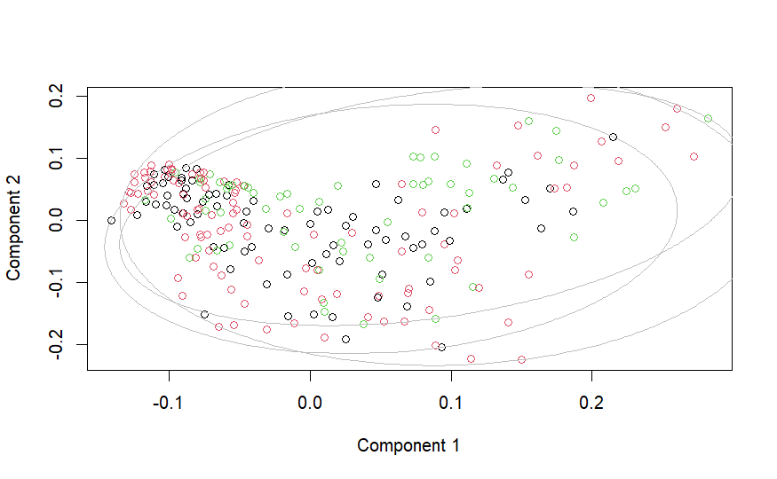

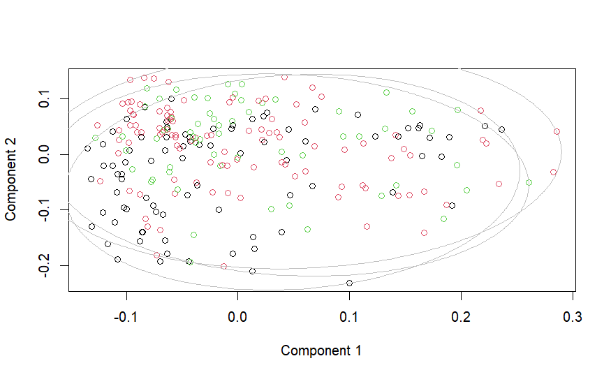

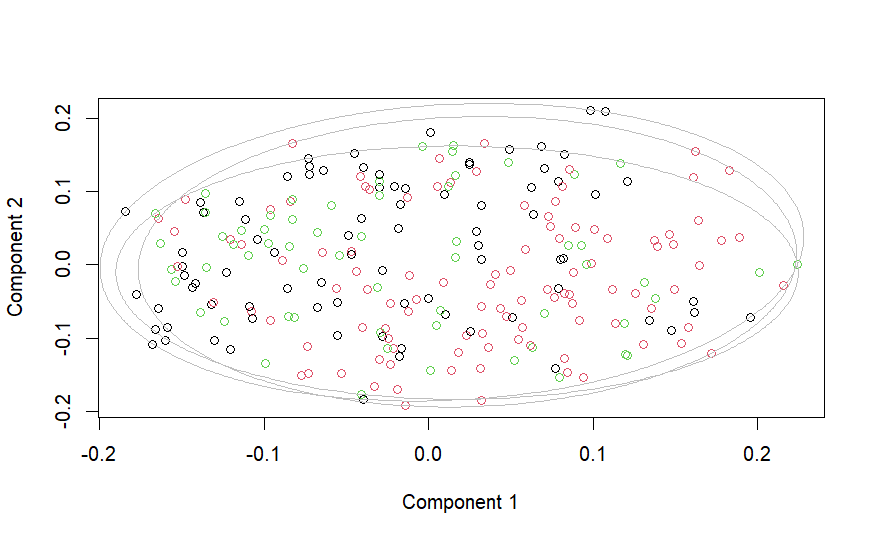

```r
for (i in 1:length(complete)){
  mds <- cmdscale(D[[i]], k = 2)
  x <- mds[,1]
  y <- mds[,2]

  samples_label <- list()
  points_label <- list()
  eh <- list()
  for(j in unique(labels)){
    samples_label[[j]] <- samples[labels[samples]==j]
    points_label[[j]] <- mds[rownames(mds) %in% samples_label[[j]], ]
    eh[[j]] <- ellipsoidhull(points_label[[j]])
  }
  plot(x,y, xlab="Component 1", ylab="Component 2", col=labels)
  for(j in unique(sc.res[[i]]))
    lines(predict(eh[[j]]),col="grey")
}
```

### 6.1.2 Data integrated through mean

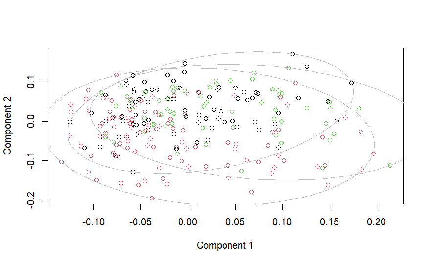

```r
mds <- cmdscale(D_mean, k = 2)
x <- mds[,1]
y <- mds[,2]

samples_label <- list()
points_label <- list()
eh <- list()
for(j in unique(labels)){
  samples_label[[j]] <- samples[labels[samples]==j]
  points_label[[j]] <- mds[rownames(mds) %in% samples_label[[j]], ]
  eh[[j]] <- ellipsoidhull(points_label[[j]])
}
plot(x,y, xlab="Component 1", ylab="Component 2", col=labels)
for(j in unique(sc.res[[i]]))
  lines(predict(eh[[j]]),col="grey")
```

### 6.1.3 Data integrated through SNF

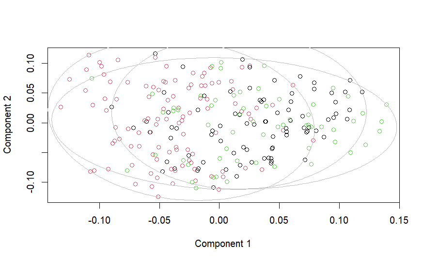

```r
mds <- cmdscale(D_SNF, k = 2)
x <- mds[,1]
y <- mds[,2]

samples_label <- list()
points_label <- list()
eh <- list()
for(j in unique(labels)){
  samples_label[[j]] <- samples[labels[samples]==j]
  points_label[[j]] <- mds[rownames(mds) %in% samples_label[[j]], ]
  eh[[j]] <- ellipsoidhull(points_label[[j]])
}
plot(x,y, xlab="Component 1", ylab="Component 2", col=labels)
for(j in unique(sc.res[[i]]))
  lines(predict(eh[[j]]),col="grey")
```

Here we prepare the labels for the chosen indices.

```r
types <- c("rand","adjrand", "jaccard",  "f", "jent",  "nmi1")
```

## 6.2 Clustering with PAM

### 6.2.1 Non-integrated data

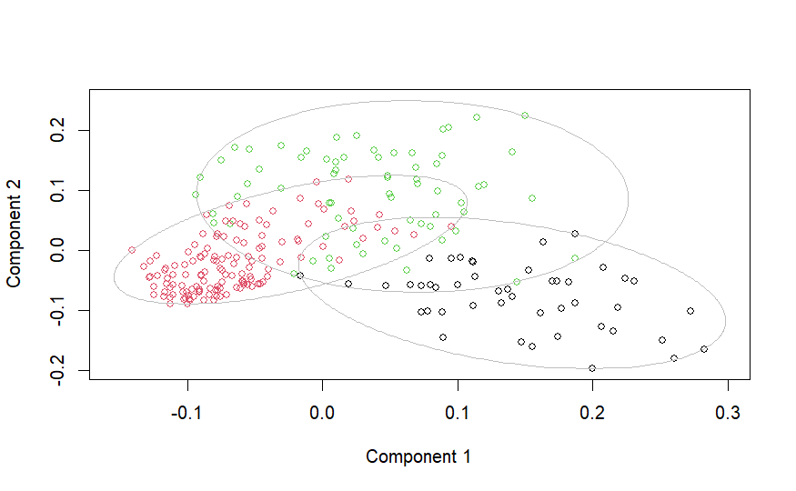

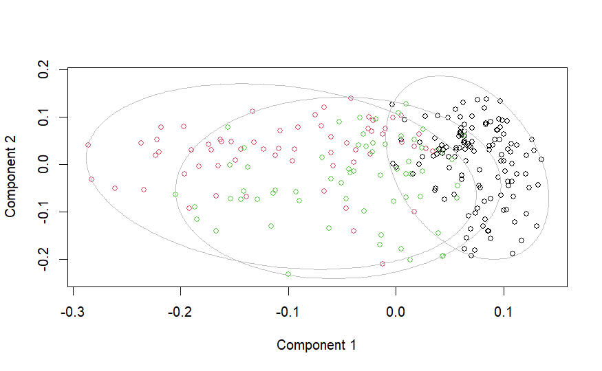

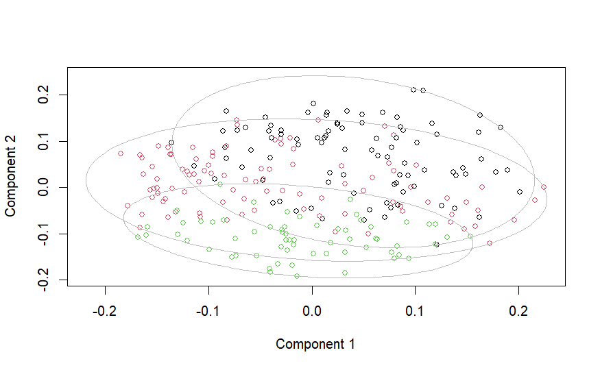

```r
for (i in 1:length(complete))
  clusplot(pam.res[[i]], main ="", sub=NULL, cex=0.9, col.p=pam.res[[i]]$cluster, plotchar=FALSE, col.clus="grey")
```

```r
NA
```

```r
for (i in 1:length(complete)){
  metrics.pam <- mclustcomp(pam.res[[i]]$clustering, labels, types=types)
  print(as.data.frame(metrics.pam))
}
```

| types | scores |
| --- | --- |
| adjrand | 0.02466935 |
| f | 98.11680616 |
| jaccard | 0.23980256 |
| jent | 2.95004823 |
| nmi1 | 0.02763638 |
| rand | 0.54241217 |

| types | scores |
| --- | --- |
| adjrand | 0.03766003 |
| f | 95.53554760 |
| jaccard | 0.23589108 |
| jent | 2.97528877 |
| nmi1 | 0.05320068 |
| rand | 0.55749641 |

| types | scores |
| --- | --- |
| adjrand | 0.007886092 |
| f | 93.389423077 |
| jaccard | 0.211298395 |
| jent | 3.081400386 |
| nmi1 | 0.019655983 |
| rand | 0.552370380 |

### 6.2.2 Data integrated though mean

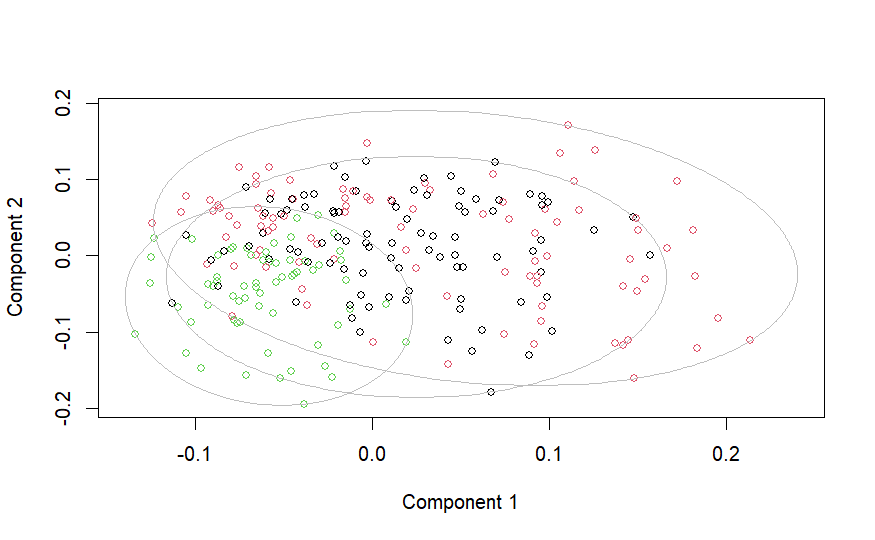

```r
clusplot(pam.mean.res, main="", sub=NULL, cex=0.9, col.p=pam.mean.res$cluster, plotchar=FALSE, col.clus="grey")
```

```r
metrics.pam <- mclustcomp(pam.mean.res$clustering, labels, types=types)

as.data.frame(metrics.pam)
```

| types | scores |
| --- | --- |
| adjrand | 0.02365087 |
| f | 93.28784661 |
| jaccard | 0.21852539 |
| jent | 3.05172577 |
| nmi1 | 0.04030343 |
| rand | 0.55981455 |

### 6.2.3 Data integrated through SNF

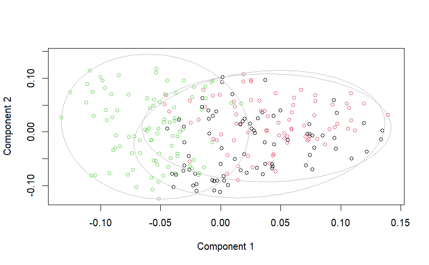

```r
clusplot(pam.SNF.res, main ="", sub=NULL, cex=0.9, col.p=pam.SNF.res$cluster, plotchar=FALSE, col.clus="grey")
```

```r
metrics.pam <- mclustcomp(pam.SNF.res$clustering, labels, types=types)

as.data.frame(metrics.pam)
```

| types | scores |
| --- | --- |
| adjrand | 0.1794663 |
| f | 92.6847450 |
| jaccard | 0.2972653 |
| jent | 2.8840141 |
| nmi1 | 0.1567445 |
| rand | 0.6316769 |

## 6.3 Spectral clustering

In this case the code to obtain the desired plots is a bit more elaborate, seen that the object returned by `SNFtool::spectralClustering` is less expressive than the one outputted by `pam`. As a result, the function `clusplot` is available only for the latter. So, in this code block we have to deduce and draw the ellipsoid hull explicitly for each cluster.

### 6.3.1 Non-integrated data

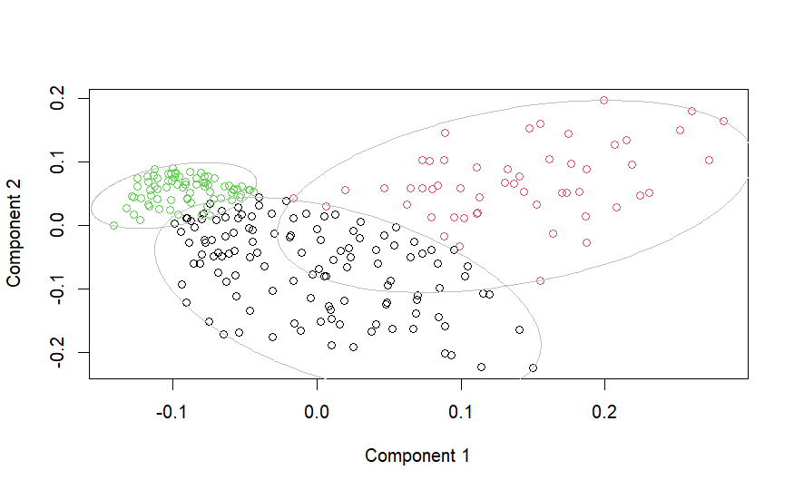

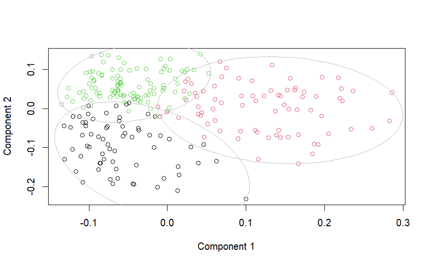

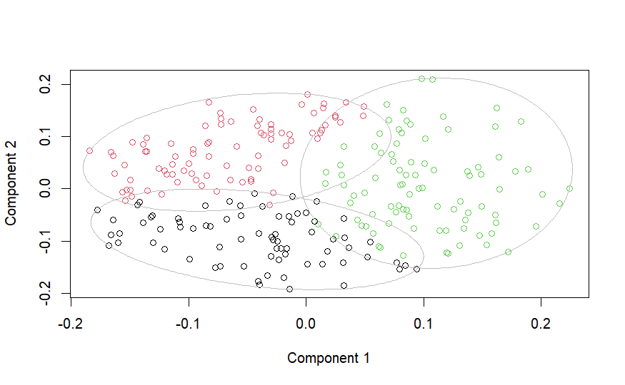

```r
for (i in 1:length(complete)){
  mds <- cmdscale(D[[i]], k = 2)
  x <- mds[,1]
  y <- mds[,2]

  samples_label <- list()
  points_label <- list()
  eh <- list()
  for(j in unique(sc.res[[i]])){
    samples_label[[j]] <- samples[sc.res[[i]][samples]==j]
    points_label[[j]] <- mds[rownames(mds) %in% samples_label[[j]], ]
    eh[[j]] <- ellipsoidhull(points_label[[j]])
  }
  plot(x,y, xlab="Component 1", ylab="Component 2", col=sc.res[[i]])
  for(j in unique(sc.res[[i]]))
    lines(predict(eh[[j]]),col="grey")
}
```

```r
for (i in 1:length(complete)){
  metrics.sc <- mclustcomp(sc.res[[i]], labels, types=types)
  print(as.data.frame(metrics.sc))
}
```

| types | scores |
| --- | --- |
| adjrand | 0.01767203 |
| f | 95.70960086 |
| jaccard | 0.22621777 |
| jent | 3.01492847 |
| nmi1 | 0.02502607 |
| rand | 0.54825650 |

| types | scores |
| --- | --- |
| adjrand | 0.04410101 |
| f | 93.50669700 |
| jaccard | 0.22982885 |
| jent | 3.03495677 |
| nmi1 | 0.04736747 |
| rand | 0.56804231 |

| types | scores |
| --- | --- |
| adjrand | 0.03343076 |
| f | 92.72429722 |
| jaccard | 0.22105016 |
| jent | 3.07021256 |
| nmi1 | 0.03714684 |
| rand | 0.56601802 |

### 6.3.2 Data integrated through mean

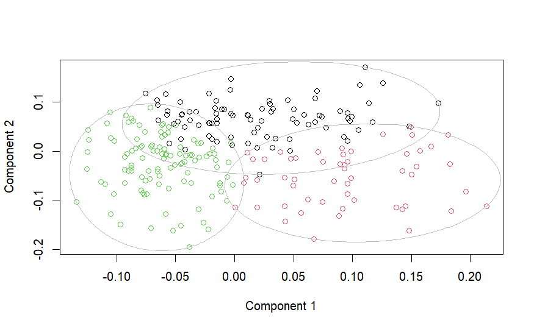

```r
mds <- cmdscale(D_mean, k = 2)
x <- mds[,1]
y <- mds[,2]

samples_label <- list()
points_label <- list()
eh <- list()
for(i in unique(sc.mean.res)){
  samples_label[[i]] <- samples[sc.mean.res[samples]==i]
  points_label[[i]] <- mds[rownames(mds) %in% samples_label[[i]], ]
  eh[[i]] <- ellipsoidhull(points_label[[i]])
}
plot(x,y, xlab="Component 1", ylab="Component 2", col=sc.mean.res)
for(i in unique(sc.mean.res))
  lines(predict(eh[[i]]), col="grey")
```

```r
metrics.sc <- mclustcomp(sc.mean.res, labels, types=types)
  print(as.data.frame(metrics.sc))
```

| types | scores |
| --- | --- |
| adjrand | 0.1425261 |
| f | 94.6885759 |
| jaccard | 0.2848604 |
| jent | 2.8911368 |
| nmi1 | 0.1225258 |
| rand | 0.6093444 |

### 6.3.3 Data integrated through SNF

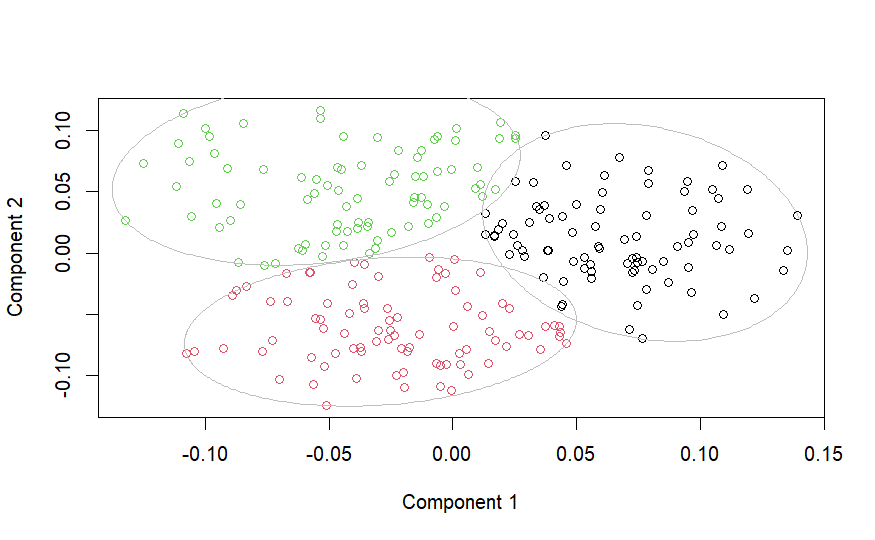

```r
mds <- cmdscale(D_SNF, k = 2)
x <- mds[,1]
y <- mds[,2]

samples_label <- list()
points_label <- list()
eh <- list()
for(i in unique(sc.SNF.res)){
  samples_label[[i]] <- samples[sc.SNF.res[samples]==i]
  points_label[[i]] <- mds[rownames(mds) %in% samples_label[[i]], ]
  eh[[i]] <- ellipsoidhull(points_label[[i]])
}
plot(x,y, xlab="Component 1", ylab="Component 2", col=sc.SNF.res)
for(i in unique(sc.SNF.res))
  lines(predict(eh[[i]]), col="grey")
```

```r
metrics.sc <- mclustcomp(sc.SNF.res, labels, types=types)
as.data.frame(metrics.sc)
```

| types | scores |
| --- | --- |
| adjrand | 0.1213365 |
| f | 92.5081939 |
| jaccard | 0.2649890 |
| jent | 2.9457976 |
| nmi1 | 0.1199149 |
| rand | 0.6061447 |

# 8 References

[1]

B. Wang, A. M. Mezlini, F. Demir, M. Fiume, Z. Tu, M. Brudno, B. Haibe-Kains, and A. Goldenberg, “Similarity network fusion for aggregating data types on a genomic scale,” *Nature methods*, vol. 11, no. 3, pp. 333–337, 2014.

[2]

R. Shen, A. B. Olshen, and M. Ladanyi, “Integrative clustering of multiple genomic data types using a joint latent variable model with application to breast and lung cancer subtype analysis,” *Bioinformatics*, vol. 25, no. 22, pp. 2906–2912, 2009.

[3]

L. Kaufman and P. J. Rousseeuw, “[Partitioning around medoids (program PAM)](https://doi.org/10.1002/9780470316801.ch2),” in *Finding groups in data*, John Wiley & Sons, Ltd, 1990, pp. 68–125.

[4]

U. Von Luxburg, “A tutorial on spectral clustering,” *Statistics and computing*, vol. 17, pp. 395–416, 2007.

[5]

A. Abeshouse, J. Ahn, R. Akbani, A. Ally, S. Amin, C. D. Andry, M. Annala, A. Aprikian, J. Armenia, A. Arora, and others, “The molecular taxonomy of primary prostate cancer,” *Cell*, vol. 163, no. 4, pp. 1011–1025, 2015.